# akinzer_07

Andrew Kinzer

March 9, 2017

```
##    Ozone Solar.R Wind Temp Month Day
## 1     41     190  7.4   67     5   1
## 2     36     118  8.0   72     5   2
## 3     12     149 12.6   74     5   3
## 4     18     313 11.5   62     5   4
## 5     NA      NA 14.3   56     5   5
## 6     28      NA 14.9   66     5   6
## 7     23     299  8.6   65     5   7
## 8     19      99 13.8   59     5   8
## 9      8      19 20.1   61     5   9
## 10    NA     194  8.6   69     5  10
## 11     7      NA  6.9   74     5  11
## 12    16     256  9.7   69     5  12
## 13    11     290  9.2   66     5  13
## 14    14     274 10.9   68     5  14
## 15    18      65 13.2   58     5  15
```

We can use the pair() function to see see what the relationship between variables is.

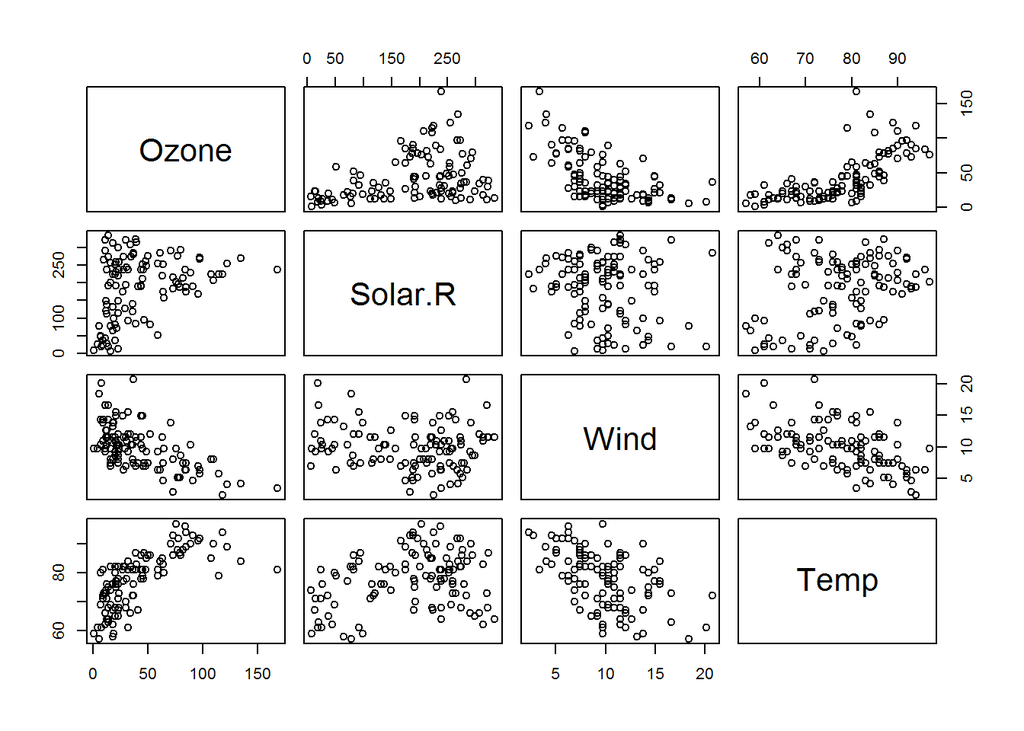

```r
pairs(airquality[,c(1:4)])
```

```r
cor(airquality[,c(1:4)], use="na.or.complete")
```

```
##              Ozone    Solar.R       Wind       Temp
## Ozone    1.0000000  0.3483417 -0.6124966  0.6985414
## Solar.R  0.3483417  1.0000000 -0.1271835  0.2940876
## Wind    -0.6124966 -0.1271835  1.0000000 -0.4971897
## Temp     0.6985414  0.2940876 -0.4971897  1.0000000
```

```r
Y = seq(from=0, to=20, by=0.1)
X1 = (Y-2)/3 + runif(length(Y), min=0.5, max=2)
X2 = (Y+3)/2 + runif(length(Y), min=0.5, max=2)
df = as.data.frame(cbind(Y, X1, X2))
summary(lm(Y~X1, data=df))
```

```
##
## Call:
## lm(formula = Y ~ X1, data = df)
##
## Residuals:
##     Min      1Q  Median      3Q     Max
## -2.6925 -1.0506  0.1459  1.1346  2.3359
##
## Coefficients:
##             Estimate Std. Error t value Pr(>|t|)
## (Intercept)  -0.8877     0.1946  -4.562 8.84e-06 ***
## X1            2.8190     0.0447  63.071  < 2e-16 ***
## ---
## Signif. codes:  0 '***' 0.001 '**' 0.01 '*' 0.05 '.' 0.1 ' ' 1
##
## Residual standard error: 1.273 on 199 degrees of freedom
## Multiple R-squared:  0.9524, Adjusted R-squared:  0.9521
## F-statistic:  3978 on 1 and 199 DF,  p-value: < 2.2e-16
```

```r
summary(lm(Y~X2, data=df))
```

```
##
## Call:
## lm(formula = Y ~ X2, data = df)
##
## Residuals:
##      Min       1Q   Median       3Q      Max
## -1.50546 -0.67997 -0.04454  0.72385  1.67821
##
## Coefficients:
##             Estimate Std. Error t value Pr(>|t|)
## (Intercept)  -5.1287     0.1702  -30.14   <2e-16 ***
## X2            1.9492     0.0205   95.09   <2e-16 ***
## ---
## Signif. codes:  0 '***' 0.001 '**' 0.01 '*' 0.05 '.' 0.1 ' ' 1
##
## Residual standard error: 0.8557 on 199 degrees of freedom
## Multiple R-squared:  0.9785, Adjusted R-squared:  0.9784
## F-statistic:  9042 on 1 and 199 DF,  p-value: < 2.2e-16
```

Both X1 and X2 seem to be significant coefficients in the model. However, when we add them together, making the model an multi-linear regression, we can see tha the variables are highly correlated.The estimate coefficients change when both variables are included in the model.

```r
summary(lm(Y~X1+X2, data=df))
```

```
##
## Call:
## lm(formula = Y ~ X1 + X2, data = df)
##
## Residuals:
##      Min       1Q   Median       3Q      Max
## -1.53388 -0.46968 -0.06536  0.43974  1.67564
##
## Coefficients:
##             Estimate Std. Error t value Pr(>|t|)
## (Intercept) -3.96014    0.17028  -23.26   <2e-16 ***
## X1           0.95237    0.08574   11.11   <2e-16 ***
## X2           1.32474    0.05849   22.65   <2e-16 ***
## ---
## Signif. codes:  0 '***' 0.001 '**' 0.01 '*' 0.05 '.' 0.1 ' ' 1
##
## Residual standard error: 0.6734 on 198 degrees of freedom
## Multiple R-squared:  0.9867, Adjusted R-squared:  0.9866
## F-statistic:  7363 on 2 and 198 DF,  p-value: < 2.2e-16
```

If we plot the two datasets we can see that they are highly correlated.

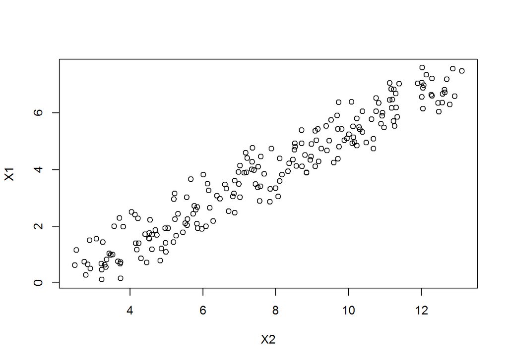

```r
plot(X1~X2)
```

Additionally, if we call up the correlation coefficient between the two of them we get…

```r
cor(X1, X2)
```

```
## [1] 0.9612175
```

This correlation coefficient shows us that the variables are highly correlated.

# Exercise 1

Manipulate the code to reduce the correlation between X1 and X2 and recalculate the regression coefficients. Explain what was found.

```r
Y2 = seq(from=0, to=20, by=0.1)
X3 = (Y2-2)/3 + runif(length(Y2), min=3, max=20)
X4 = (Y2+3)/2 + runif(length(Y2), min=0.5, max=1)
df = as.data.frame(cbind(Y2, X3, X4))
summary(lm(Y2~X3, data=df))
```

```
##
## Call:
## lm(formula = Y2 ~ X3, data = df)
##
## Residuals:
##      Min       1Q   Median       3Q      Max
## -11.5056  -4.3409   0.2238   4.3310  10.8909
##
## Coefficients:
##             Estimate Std. Error t value Pr(>|t|)
## (Intercept)  4.01681    1.03246   3.891 0.000136 ***
## X3           0.43419    0.06977   6.223 2.83e-09 ***
## ---
## Signif. codes:  0 '***' 0.001 '**' 0.01 '*' 0.05 '.' 0.1 ' ' 1
##
## Residual standard error: 5.335 on 199 degrees of freedom
## Multiple R-squared:  0.1629, Adjusted R-squared:  0.1587
## F-statistic: 38.73 on 1 and 199 DF,  p-value: 2.827e-09
```

```r
summary(lm(Y2~X4, data=df))
```

```
##
## Call:
## lm(formula = Y2 ~ X4, data = df)
##
## Residuals:
##      Min       1Q   Median       3Q      Max
## -0.49559 -0.26414  0.00044  0.25497  0.55201
##
## Coefficients:
##              Estimate Std. Error t value Pr(>|t|)
## (Intercept) -4.460621   0.057912  -77.02   <2e-16 ***
## X4           1.990450   0.007399  269.00   <2e-16 ***
## ---
## Signif. codes:  0 '***' 0.001 '**' 0.01 '*' 0.05 '.' 0.1 ' ' 1
##
## Residual standard error: 0.3054 on 199 degrees of freedom
## Multiple R-squared:  0.9973, Adjusted R-squared:  0.9972
## F-statistic: 7.236e+04 on 1 and 199 DF,  p-value: < 2.2e-16
```

If we run the summary with them combined we get:

```r
summary(lm(Y2~X3+X4, data=df))
```

```
##
## Call:
## lm(formula = Y2 ~ X3 + X4, data = df)
##
## Residuals:
##      Min       1Q   Median       3Q      Max
## -0.51964 -0.27014  0.00238  0.25519  0.55223
##
## Coefficients:
##              Estimate Std. Error t value Pr(>|t|)
## (Intercept) -4.484118   0.068556 -65.408   <2e-16 ***
## X3           0.002808   0.004368   0.643    0.521
## X4           1.988358   0.008093 245.686   <2e-16 ***
## ---
## Signif. codes:  0 '***' 0.001 '**' 0.01 '*' 0.05 '.' 0.1 ' ' 1
##
## Residual standard error: 0.3058 on 198 degrees of freedom
## Multiple R-squared:  0.9973, Adjusted R-squared:  0.9972
## F-statistic: 3.607e+04 on 2 and 198 DF,  p-value: < 2.2e-16
```

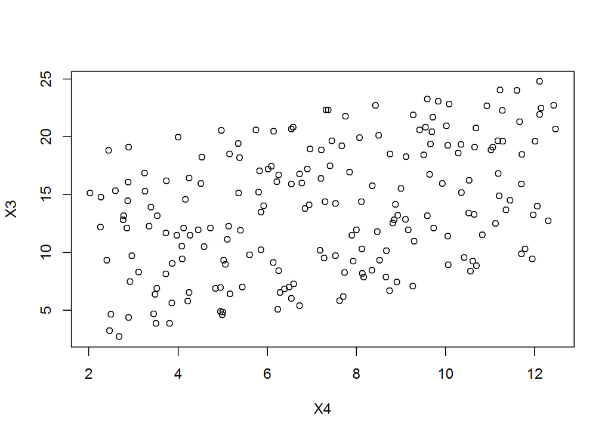

```r
plot(X3~X4)
```

What I found is that I could increase the amount of noise in the data by changing the length of the noise for Y in each of the X3 and X4 formulas. The length of X3 is going from 3-20, so quite a lot of noise around the mean, and the length of x4 is from 0.5-1, very smallamount of noise around the line. This ended up reducing the level of correlation between the variables.

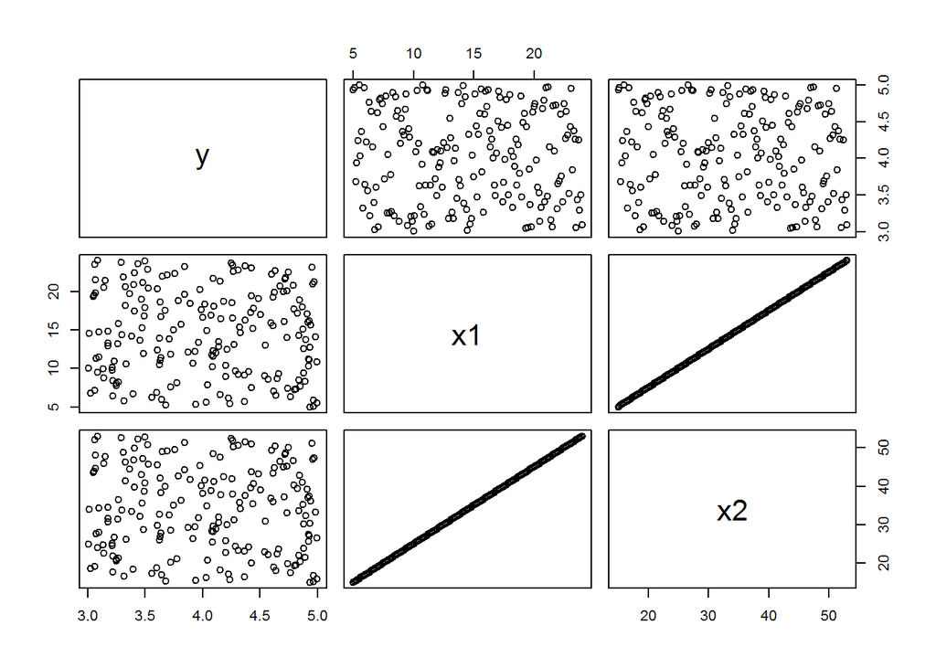

```r
y=seq(from=1, to=20, by=0.1)
y=runif(length(y), min=3, max=5)
x1=seq(from=5, to=24, by=0.1)
x2=x1*2+5
df = data.frame(y, x1, x2)
pairs(df)
```

```r
summary(lm(y~x1+x2))
```

```
##
## Call:
## lm(formula = y ~ x1 + x2)
##
## Residuals:
##      Min       1Q   Median       3Q      Max
## -1.05445 -0.54399  0.03983  0.58359  0.97886
##
## Coefficients: (1 not defined because of singularities)
##              Estimate Std. Error t value Pr(>|t|)
## (Intercept)  4.114571   0.127141  32.362   <2e-16 ***
## x1          -0.005581   0.008196  -0.681    0.497
## x2                 NA         NA      NA       NA
## ---
## Signif. codes:  0 '***' 0.001 '**' 0.01 '*' 0.05 '.' 0.1 ' ' 1
##
## Residual standard error: 0.6245 on 189 degrees of freedom
## Multiple R-squared:  0.002448,   Adjusted R-squared:  -0.00283
## F-statistic: 0.4638 on 1 and 189 DF,  p-value: 0.4967
```

We get the NA value for X2 because X1 and X2 are exaclty the same, or perfectly correlated.

```r
mod1 = lm(Temp~Wind, data=airquality)
summary(mod1)
```

```
##
## Call:
## lm(formula = Temp ~ Wind, data = airquality)
##
## Residuals:
##     Min      1Q  Median      3Q     Max
## -19.112  -5.646   1.014   6.254  18.888
##
## Coefficients:
##             Estimate Std. Error t value Pr(>|t|)
## (Intercept)  91.0305     2.3489  38.754  < 2e-16 ***
## Wind         -1.3318     0.2226  -5.983 2.84e-08 ***
## ---
## Signif. codes:  0 '***' 0.001 '**' 0.01 '*' 0.05 '.' 0.1 ' ' 1
##
## Residual standard error: 8.306 on 109 degrees of freedom
## Multiple R-squared:  0.2472, Adjusted R-squared:  0.2403
## F-statistic: 35.79 on 1 and 109 DF,  p-value: 2.842e-08
```

The F-test only works when models are nested in each other.

```r
mod2 = lm(Temp~Wind+Solar.R, data=airquality)
summary(mod2)
```

```
##
## Call:
## lm(formula = Temp ~ Wind + Solar.R, data = airquality)
##
## Residuals:
##      Min       1Q   Median       3Q      Max
## -17.2714  -5.0237   0.5837   5.2545  18.4608
##
## Coefficients:
##              Estimate Std. Error t value Pr(>|t|)
## (Intercept) 85.702275   2.925445  29.295  < 2e-16 ***
## Wind        -1.251870   0.217207  -5.763 7.89e-08 ***
## Solar.R      0.024533   0.008478   2.894  0.00461 **
## ---
## Signif. codes:  0 '***' 0.001 '**' 0.01 '*' 0.05 '.' 0.1 ' ' 1
##
## Residual standard error: 8.039 on 108 degrees of freedom
## Multiple R-squared:  0.3014, Adjusted R-squared:  0.2884
## F-statistic: 23.29 on 2 and 108 DF,  p-value: 3.886e-09
```

```r
anova(mod1, mod2)
```

```
## Analysis of Variance Table
##
## Model 1: Temp ~ Wind
## Model 2: Temp ~ Wind + Solar.R
##   Res.Df    RSS Df Sum of Sq      F   Pr(>F)
## 1    109 7520.7
## 2    108 6979.5  1    541.17 8.3739 0.004606 **
## ---
## Signif. codes:  0 '***' 0.001 '**' 0.01 '*' 0.05 '.' 0.1 ' ' 1
```

IS the reduction in the residual sum of squares significant or not? Because the P-value is 0.0046, the drop is significant, which says that model 2 explains a greater amount of variance than model 1.

# Exercise 2

Compare a third model (mod3) with ozone as a third variable to mod1 and mod2. Does it explain more variance? Does it give you a reasonable estimate of the regression coefficients.

```r
mod1 = lm(Temp~Wind, data=airquality)
mod2 = lm(Temp~Wind+Solar.R, data=airquality)
mod3 = lm(Temp~Wind+Solar.R+Ozone, data=airquality)
summary(mod1)
```

```
##
## Call:
## lm(formula = Temp ~ Wind, data = airquality)
##
## Residuals:
##     Min      1Q  Median      3Q     Max
## -19.112  -5.646   1.014   6.254  18.888
##
## Coefficients:
##             Estimate Std. Error t value Pr(>|t|)
## (Intercept)  91.0305     2.3489  38.754  < 2e-16 ***
## Wind         -1.3318     0.2226  -5.983 2.84e-08 ***
## ---
## Signif. codes:  0 '***' 0.001 '**' 0.01 '*' 0.05 '.' 0.1 ' ' 1
##
## Residual standard error: 8.306 on 109 degrees of freedom
## Multiple R-squared:  0.2472, Adjusted R-squared:  0.2403
## F-statistic: 35.79 on 1 and 109 DF,  p-value: 2.842e-08
```

```r
summary(mod2)
```

```
##
## Call:
## lm(formula = Temp ~ Wind + Solar.R, data = airquality)
##
## Residuals:
##      Min       1Q   Median       3Q      Max
## -17.2714  -5.0237   0.5837   5.2545  18.4608
##
## Coefficients:
##              Estimate Std. Error t value Pr(>|t|)
## (Intercept) 85.702275   2.925445  29.295  < 2e-16 ***
## Wind        -1.251870   0.217207  -5.763 7.89e-08 ***
## Solar.R      0.024533   0.008478   2.894  0.00461 **
## ---
## Signif. codes:  0 '***' 0.001 '**' 0.01 '*' 0.05 '.' 0.1 ' ' 1
##
## Residual standard error: 8.039 on 108 degrees of freedom
## Multiple R-squared:  0.3014, Adjusted R-squared:  0.2884
## F-statistic: 23.29 on 2 and 108 DF,  p-value: 3.886e-09
```

```r
summary(mod3)
```

```
##
## Call:
## lm(formula = Temp ~ Wind + Solar.R + Ozone, data = airquality)
##
## Residuals:
##     Min      1Q  Median      3Q     Max
## -20.942  -4.996   1.283   4.434  13.168
##
## Coefficients:
##              Estimate Std. Error t value Pr(>|t|)
## (Intercept) 72.418579   3.215525  22.522  < 2e-16 ***
## Wind        -0.322945   0.233264  -1.384    0.169
## Solar.R      0.007276   0.007678   0.948    0.345
## Ozone        0.171966   0.026390   6.516 2.42e-09 ***
## ---
## Signif. codes:  0 '***' 0.001 '**' 0.01 '*' 0.05 '.' 0.1 ' ' 1
##
## Residual standard error: 6.834 on 107 degrees of freedom
## Multiple R-squared:  0.4999, Adjusted R-squared:  0.4858
## F-statistic: 35.65 on 3 and 107 DF,  p-value: 4.729e-16
```

Adding in Ozone does explain more more variance (Higher adjusted R<sup>2</sup> value than the other models).

Additionally, when Ozone is added to the model, the other two factors, Wind and Solar, are no longer significant. This would indicate that ozone has a much stronger effect on temperature than the other two factors, as well as explaining more of the variance.

If we run an anova() function to compare all three models, we can futher explore the effectiveness of each one.

```r
anova(mod1,mod2,mod3)
```

```
## Analysis of Variance Table
##
## Model 1: Temp ~ Wind
## Model 2: Temp ~ Wind + Solar.R
## Model 3: Temp ~ Wind + Solar.R + Ozone
##   Res.Df    RSS Df Sum of Sq      F    Pr(>F)
## 1    109 7520.7
## 2    108 6979.5  1    541.17 11.589 0.0009349 ***
## 3    107 4996.6  1   1982.90 42.463 2.424e-09 ***
## ---
## Signif. codes:  0 '***' 0.001 '**' 0.01 '*' 0.05 '.' 0.1 ' ' 1
```

The RSS values further show that model three, with RSS=4996.6, is the most effective model, as it has the smallest RSS, and the likelihood of any of the other models explaing more of the variance is 2.42e-9, which is much smaller than the value for model2.

# Exercise 2 Bonus

Bonus: calculate the RSS of the two models, the F statistic, and the p value by hand, not using anova….

```r
res = residuals(mod1)
RSS1 = sum(res^2)
RSS1
```

```
## [1] 7520.672
```

```r
res = residuals(mod2)
RSS2 = sum(res^2)
RSS2
```

```
## [1] 6979.506
```

```r
fstat=((RSS1-RSS2)/(3-2))/((RSS2)/summary(mod2)$df[2])
fstat
```

```
## [1] 8.373933
```

As we can see above, the F-stat=8.374 between the two models.

To calculate the p-value from the fstat:

```r
1-pf(fstat, df1=1, df2=nrow(airquality)-3)
```

```
## [1] 0.004605629
```

We got it! A matching p-value and a matching f-statistic manually! We can confirm it by running an anova() with mod1 and mod2.

```r
anova(mod1,mod2)
```

```
## Analysis of Variance Table
##
## Model 1: Temp ~ Wind
## Model 2: Temp ~ Wind + Solar.R
##   Res.Df    RSS Df Sum of Sq      F   Pr(>F)
## 1    109 7520.7
## 2    108 6979.5  1    541.17 8.3739 0.004606 **
## ---
## Signif. codes:  0 '***' 0.001 '**' 0.01 '*' 0.05 '.' 0.1 ' ' 1
```

# Exercise3

Compare the AIC of mod1, mod2, and mod3. Do you have different conclusion in terms of which model performs better?

```r
AIC(mod1,mod2,mod3)
```

```
##      df      AIC
## mod1  3 788.9671
## mod2  4 782.6779
## mod3  5 747.5795
```

Based on the AIC value, mod3 is still the best model in explaining the data. We can say that mod3 explains more variation than the other two models, without losing information.